# Data Collection

## 📊 Loading and Previewing GDP Data

In this cell, we:

1. **Import necessary libraries**: `pandas` for data handling and `matplotlib.pyplot` for visualization.
2. **Load three datasets**:
   - `real_gdp_growth.xls`: Contains real GDP growth data (annual % change).
   - `gdp_current_prices.xls`: Contains GDP in current prices (billion USD).
   - `gdp_per_capita.xls`: Contains GDP per capita (USD).
3. **Preview the first few rows** of each dataset using `print(df.head())`.

```python
import pandas as pd
import matplotlib.pyplot as plt

real_gdp_growth_path = 'real_gdp_growth.xls'
gdp_current_prices_path = 'gdp_current_prices.xls'
gdp_per_capita_path = 'gdp_per_capita.xls'

real_gdp_growth = pd.read_excel(real_gdp_growth_path, engine='xlrd')
gdp_current_prices = pd.read_excel(gdp_current_prices_path, engine='xlrd')
gdp_per_capita = pd.read_excel(gdp_per_capita_path, engine='xlrd')

print(real_gdp_growth.head())

print(gdp_current_prices.head())

print(gdp_per_capita.head())
```

```
  Real GDP growth (Annual percent change)  1980  1981  1982  1983  1984  1985  \
0                                     NaN   NaN   NaN   NaN   NaN   NaN   NaN
1                                Bulgaria   5.7   5.3   4.2   3.0   4.6   1.8
2                                     NaN   NaN   NaN   NaN   NaN   NaN   NaN
3                              ©IMF, 2024   NaN   NaN   NaN   NaN   NaN   NaN

   1986  1987  1988  ...  2020  2021  2022  2023  2024  2025  2026  2027  \
0   NaN   NaN   NaN  ...   NaN   NaN   NaN   NaN   NaN   NaN   NaN   NaN
1   5.3   4.7   2.4  ...  -4.0   7.7   3.9   1.8   2.3   2.5   2.8   2.7
2   NaN   NaN   NaN  ...   NaN   NaN   NaN   NaN   NaN   NaN   NaN   NaN
3   NaN   NaN   NaN  ...   NaN   NaN   NaN   NaN   NaN   NaN   NaN   NaN

   2028  2029
0   NaN   NaN
1   2.7   2.6
```

[output cut: 48 more lines]

## 🧹 Cleaning the Data: Removing Unnecessary Columns

In this step, we remove the **first column** from each dataset, as it contains country name instead of numerical values.

### 📌 Key Actions:

1. **Drop the first column** (`columns[0]`) from:
   - `real_gdp_growth`
   - `gdp_current_prices`
   - `gdp_per_capita`
2. **Preview the cleaned data** using `head()`.

```python
real_gdp_growth = real_gdp_growth.drop(real_gdp_growth.columns[0], axis=1)
gdp_current_prices = gdp_current_prices.drop(gdp_current_prices.columns[0], axis=1)
gdp_per_capita = gdp_per_capita.drop(gdp_per_capita.columns[0], axis=1)

print(real_gdp_growth.head())

print(gdp_current_prices.head())

print(gdp_per_capita.head())
```

```
   1980  1981  1982  1983  1984  1985  1986  1987  1988  1989  ...  2020  \
0   NaN   NaN   NaN   NaN   NaN   NaN   NaN   NaN   NaN   NaN  ...   NaN
1   5.7   5.3   4.2   3.0   4.6   1.8   5.3   4.7   2.4  -0.5  ...  -4.0
2   NaN   NaN   NaN   NaN   NaN   NaN   NaN   NaN   NaN   NaN  ...   NaN
3   NaN   NaN   NaN   NaN   NaN   NaN   NaN   NaN   NaN   NaN  ...   NaN

   2021  2022  2023  2024  2025  2026  2027  2028  2029
0   NaN   NaN   NaN   NaN   NaN   NaN   NaN   NaN   NaN
1   7.7   3.9   1.8   2.3   2.5   2.8   2.7   2.7   2.6
2   NaN   NaN   NaN   NaN   NaN   NaN   NaN   NaN   NaN
3   NaN   NaN   NaN   NaN   NaN   NaN   NaN   NaN   NaN

[4 rows x 50 columns]
     1980    1981    1982    1983    1984    1985   1986    1987    1988  \
0     NaN     NaN     NaN     NaN     NaN     NaN    NaN     NaN     NaN
```

[output cut: 36 more lines]

## 🧼 Cleaning the Data: Removing Empty Rows

In this step, we **remove completely empty rows** from each dataset using `.dropna(how='all')`.

### 📌 Key Actions:

1. **Drop rows where all values are NaN** in:
   - `real_gdp_growth`
   - `gdp_current_prices`
   - `gdp_per_capita`
2. **Display the cleaned data** using `head()`.

```python
real_gdp_growth = real_gdp_growth.dropna(how='all')
gdp_current_prices = gdp_current_prices.dropna(how='all')
gdp_per_capita = gdp_per_capita.dropna(how='all')

print(real_gdp_growth.head())

print(gdp_current_prices.head())

print(gdp_per_capita.head())
```

```
   1980  1981  1982  1983  1984  1985  1986  1987  1988  1989  ...  2020  \
1   5.7   5.3   4.2   3.0   4.6   1.8   5.3   4.7   2.4  -0.5  ...  -4.0

   2021  2022  2023  2024  2025  2026  2027  2028  2029
1   7.7   3.9   1.8   2.3   2.5   2.8   2.7   2.7   2.6

[1 rows x 50 columns]
     1980    1981    1982    1983    1984    1985   1986    1987    1988  \
1  37.751  40.718  42.467  43.641  46.358  39.692  35.13  40.721  66.546

     1989  ...    2020  2021    2022     2023     2024     2025     2026  \
1  67.774  ...  70.311  84.1  90.422  101.611  108.425  115.531  121.858

      2027   2028     2029
1  128.062  134.1  140.758

[1 rows x 50 columns]
       1980      1981      1982      1983      1984     1985      1986  \
1  4286.209  4609.426  4793.655  4913.838  5210.542  4458.09  3946.885

       1987      1988      1989  ...      2020       2021       2022  \
1  4581.216  7506.638  7678.816  ...  10165.58  12297.273  14023.892

        2023      2024       2025       2026       2027       2028       2029
1  15764.648  17069.33  18455.625  19623.357  20788.672  21944.424  23219.811

[1 rows x 50 columns]
```

## 📊 Visualizing Bulgaria's GDP Data

### 📌 Steps Performed:

1. **Data Cleaning:**
   - Removed empty rows and unnecessary columns.
   - Converted indices to integer years.
2. **Data Transformation:**
   - Reformatted the datasets into DataFrames with appropriate labels:
     - `real_gdp_growth`: Annual GDP growth rates (%).
     - `gdp_current_prices`: GDP in billion USD.
     - `gdp_per_capita`: GDP per capita in USD.
3. **Data Visualization:**
   - **Line Plot**: GDP at current prices over the years.
   - **Bar Chart**: Real GDP growth rate.
   - **Line Plot**: GDP per capita over the years.

### 📈 Generated Plots:

1. **Bulgaria GDP at Current Prices (Billions USD)**
   - Line plot with markers to visualize GDP trends over the years.
2. **Bulgaria Real GDP Growth Rate (%)**
   - Bar chart to show yearly GDP growth fluctuations.
3. **Bulgaria GDP per Capita (USD)**
   - Line plot illustrating GDP per capita changes over time.

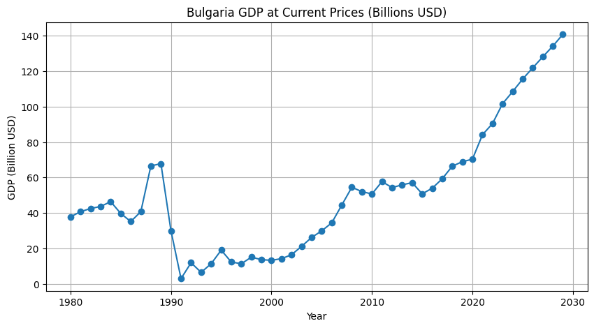

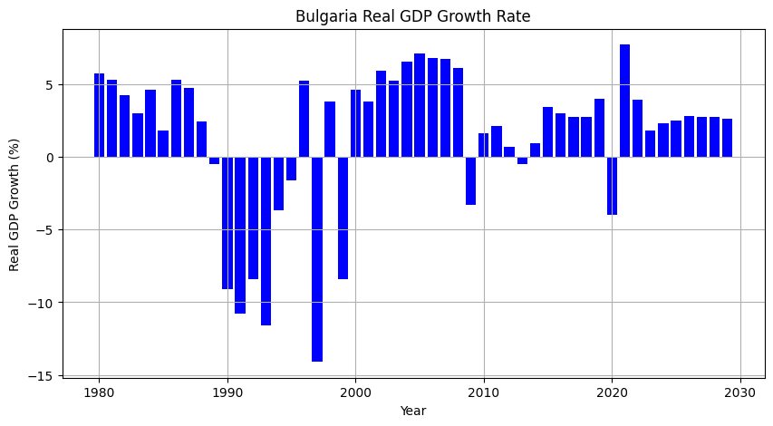

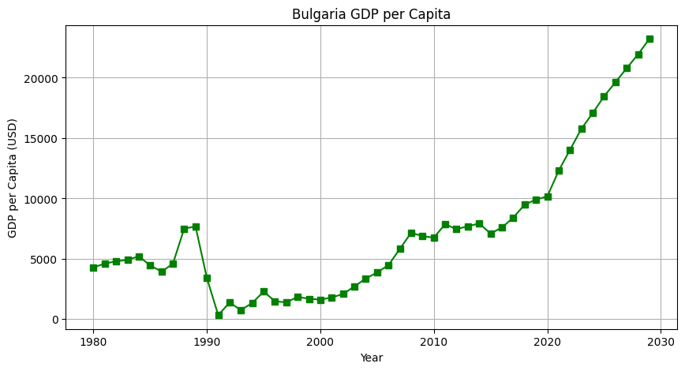

```
      GDP per Capita (USD)
1980              4286.209
1981              4609.426
1982              4793.655
1983              4913.838
1984              5210.542
Index(['GDP per Capita (USD)'], dtype='object')
      Real GDP Growth
1980              5.7
1981              5.3
1982              4.2
1983              3.0
1984              4.6
Index(['Real GDP Growth'], dtype='object')
      GDP (Billion USD)
1980             37.751
1981             40.718
1982             42.467
1983             43.641
1984             46.358
Index(['GDP (Billion USD)'], dtype='object')
```

```python
real_gdp_growth_path = 'real_gdp_growth.xls'
gdp_current_prices_path = 'gdp_current_prices.xls'
gdp_per_capita_path = 'gdp_per_capita.xls'

real_gdp_growth = pd.read_excel(real_gdp_growth_path, engine='xlrd')
gdp_current_prices = pd.read_excel(gdp_current_prices_path, engine='xlrd')
gdp_per_capita = pd.read_excel(gdp_per_capita_path, engine='xlrd')

real_gdp_growth = real_gdp_growth.drop(real_gdp_growth.columns[0], axis=1).dropna(how='all')
gdp_current_prices = gdp_current_prices.drop(gdp_current_prices.columns[0], axis=1).dropna(how='all')
gdp_per_capita = gdp_per_capita.drop(gdp_per_capita.columns[0], axis=1).dropna(how='all')

years = real_gdp_growth.columns.astype(int)
real_gdp_growth = pd.DataFrame(real_gdp_growth.iloc[0].values, index=years, columns=['Real GDP Growth'])
gdp_current_prices = pd.DataFrame(gdp_current_prices.iloc[0].values, index=years, columns=['GDP (Billion USD)'])
gdp_per_capita = pd.DataFrame(gdp_per_capita.iloc[0].values, index=years, columns=['GDP per Capita (USD)'])

plt.figure(figsize=(10, 5))
plt.plot(gdp_current_prices, marker='o', linestyle='-')
plt.xlabel("Year")
plt.ylabel("GDP (Billion USD)")
plt.title("Bulgaria GDP at Current Prices (Billions USD)")
plt.grid()
plt.show()

plt.figure(figsize=(10, 5))
plt.bar(real_gdp_growth.index, real_gdp_growth['Real GDP Growth'], color='b')
plt.xlabel("Year")
plt.ylabel("Real GDP Growth (%)")
plt.title("Bulgaria Real GDP Growth Rate")
plt.grid()
plt.show()

plt.figure(figsize=(10, 5))
plt.plot(gdp_per_capita, marker='s', linestyle='-', color='g')
plt.xlabel("Year")
plt.ylabel("GDP per Capita (USD)")
plt.title("Bulgaria GDP per Capita")
plt.grid()
plt.show()

print(gdp_per_capita.head())
print(gdp_per_capita.columns)

print(real_gdp_growth.head())
print(real_gdp_growth.columns)

print(gdp_current_prices.head())
print(gdp_current_prices.columns)
```

# 📊 GDP vs. GDP per Capita Over Time

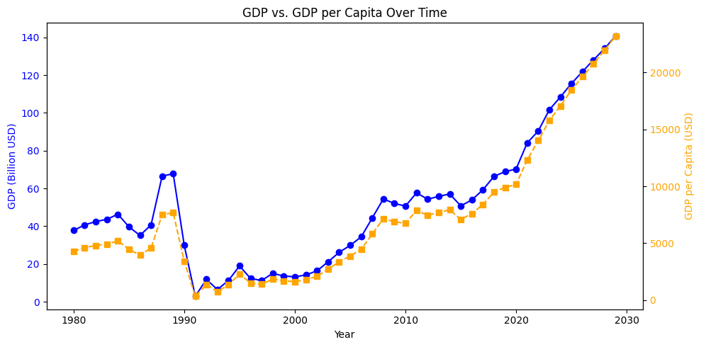

```python
fig, ax1 = plt.subplots(figsize=(10, 5))

ax1.set_xlabel("Year")
ax1.set_ylabel("GDP (Billion USD)", color='blue')
ax1.plot(gdp_current_prices.index, gdp_current_prices.iloc[:, 0], label="GDP (Billion USD)", color='blue', marker='o', linestyle='-')
ax1.tick_params(axis='y', labelcolor='blue')

ax2 = ax1.twinx()
ax2.set_ylabel("GDP per Capita (USD)", color='orange')
ax2.plot(gdp_per_capita.index, gdp_per_capita.iloc[:, 0], label="GDP per Capita (USD)", color='orange', marker='s', linestyle='--')
ax2.tick_params(axis='y', labelcolor='orange')

plt.title("GDP vs. GDP per Capita Over Time")
fig.tight_layout()
plt.show()
```

## 📈 Insights from the Graph:

- **Sharp dips** in real GDP growth around **1990 and 1997**, likely due to economic crises or structural reforms.
- **High volatility** in GDP growth rates between **1990–2010**, indicating economic instability.
- **Post-2010 stabilization**, where GDP growth fluctuates less and aligns with an upward trend in overall GDP.
- **Projected growth** post-2020 suggests continued economic expansion.

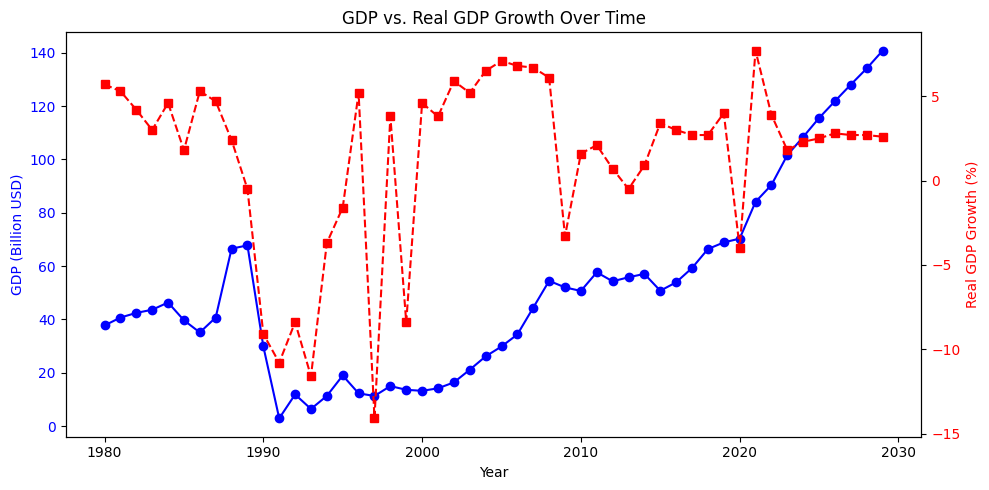

```python
fig, ax1 = plt.subplots(figsize=(10, 5))

ax1.set_xlabel("Year")
ax1.set_ylabel("GDP (Billion USD)", color='blue')
ax1.plot(gdp_current_prices.index, gdp_current_prices.iloc[:, 0], label="GDP (Billion USD)", color='blue', marker='o', linestyle='-')
ax1.tick_params(axis='y', labelcolor='blue')

ax2 = ax1.twinx()
ax2.set_ylabel("Real GDP Growth (%)", color='red')
ax2.plot(real_gdp_growth.index, real_gdp_growth.iloc[:, 0], label="Real GDP Growth (%)", color='red', marker='s', linestyle='--')
ax2.tick_params(axis='y', labelcolor='red')

plt.title("GDP vs. Real GDP Growth Over Time")
fig.tight_layout()
plt.show()
```